# Heart Prediction Model

Farrah Johnson and Mariam Ikram

2026-04-20

# Introduction

This data is a CSV from Kaggle based on 5 conjoined datasets on patients with heart disease around the world. This data combined 11 factors that shows the strongest correlation with the onset of heart failure with a total of 918 observations.

# Problems and Questions

Women have been historically medically underdiagnosed, so to understand heart failure statistics, we will be evaluating:

- How do women and men differ in total heart failure statistics?
- What leading factors contribute to heart disease the most?
- What are the important demographics of the sample and how do they correlate?

# What libraries did you use?

- tidyverse: data wrangling (dplyr), plotting (ggplot2), and general data manipulation (forcats)
- janitor: cleans columns names and simple tabulations
- knitr: Create nice tables in the report
- kableExtra: Enhancing table appearance (border, alignment, etc.)
- ggthemes: better color themes for data distribution
- ggdist: For visualizing data distribution in a more efficient way
- ggbeeswarm: Enhances points for categorical data in raincloud plots

# Our unfilitered data

```
## Rows: 918
## Columns: 12
## $ Age            <int> 40, 49, 37, 48, 54, 39, 45, 54, 37, 48, 37, 58, 39, 49,…
## $ Sex            <chr> "M", "F", "M", "F", "M", "M", "F", "M", "M", "F", "F", …
## $ ChestPainType  <chr> "ATA", "NAP", "ATA", "ASY", "NAP", "NAP", "ATA", "ATA",…
## $ RestingBP      <int> 140, 160, 130, 138, 150, 120, 130, 110, 140, 120, 130, …
## $ Cholesterol    <int> 289, 180, 283, 214, 195, 339, 237, 208, 207, 284, 211, …
## $ FastingBS      <int> 0, 0, 0, 0, 0, 0, 0, 0, 0, 0, 0, 0, 0, 0, 0, 0, 0, 0, 0…
## $ RestingECG     <chr> "Normal", "Normal", "ST", "Normal", "Normal", "Normal",…
## $ MaxHR          <int> 172, 156, 98, 108, 122, 170, 170, 142, 130, 120, 142, 9…
## $ ExerciseAngina <chr> "N", "N", "N", "Y", "N", "N", "N", "N", "Y", "N", "N", …
## $ Oldpeak        <dbl> 0.0, 1.0, 0.0, 1.5, 0.0, 0.0, 0.0, 0.0, 1.5, 0.0, 0.0, …
## $ ST_Slope       <chr> "Up", "Flat", "Up", "Flat", "Up", "Up", "Up", "Up", "Fl…
## $ HeartDisease   <int> 0, 1, 0, 1, 0, 0, 0, 0, 1, 0, 0, 1, 0, 1, 0, 0, 1, 0, 1…
```

We first read in the CSV file and use glimpse() to inspect the raw imported data. We’ll go more into the important pieces of information that we pulled from this dataset on the next slide, as not all data had a surprising correlation with our hypothesis.

# Leading indications of heart disease

Several variables in this dataset come from electrocardiograms (ECG) and exercise stress tests. These exercises help determine how the heart responds to physical activity and whether blood flow to the heart is reduced.

- ST Segment/ ST-T Wave: The ST segment is part of the ECG waveform. Abnormal changes in this segment can indicate reduced blood flow to the heart (ischemia) or other electrical disturbances.
- LV Hypertrophy (Left Ventricular Hypertrophy): occurs ventricle- the main pumping chamber of the heart- becomes thickened. Often resulting from long standing high blood pressure or other conditions that forces the heart to work harder. LV Hypertrophy is important because it increases the risk heart failure, and other cardiac events.
- Oldpeak: This measures how much the ST segment drops during the exercise compared to rest. Higher values often indicate that the heart is not receiving enough oxygen.
- ST Slope: This describes the direction of the ST segment during peak exercise (upsloping, flat, downsloping). A flat or down sloping line is commonly associated with heart disease.
- Exercise Angina: Indicates whether the patient experienced chest pain during exercise, which can be a sign of reduced oxygen supply to the heart.

# Cleaned dataset

- We use `clean_names()` to standardize the column names. This makes it easier to reference variables in the rest of the analysis (for example, `chest_pain_type` instead of `ChestPainType`).
- Next we mutate our dataset, recoding clinical abbreviations with their full descriptive names. Now values such as `M` and `F` are now `Male` and `Female`, along with several others.
- We use `fct_recode()` as opposed to simply converting variables to factors, because `fct_recode()` allows us to explicitly map each original value to a new, more readable label, improving clarity, reducing the chance of errors, and making the dataset easier to interpret in later summaries, analysis, and visualizations.

```
## Rows: 918
## Columns: 12
## $ age             <int> 40, 49, 37, 48, 54, 39, 45, 54, 37, 48, 37, 58, 39, 49…
## $ sex             <fct> Male, Female, Male, Female, Male, Male, Female, Male, …
## $ chest_pain_type <fct> Atypical Angina, Non-Anginal Pain, Atypical Angina, As…
## $ resting_bp      <int> 140, 160, 130, 138, 150, 120, 130, 110, 140, 120, 130,…
## $ cholesterol     <int> 289, 180, 283, 214, 195, 339, 237, 208, 207, 284, 211,…
## $ fasting_bs      <fct> No, No, No, No, No, No, No, No, No, No, No, No, No, No…
## $ resting_ecg     <fct> Normal, Normal, ST-T Abnormality, Normal, Normal, Norm…
## $ max_hr          <int> 172, 156, 98, 108, 122, 170, 170, 142, 130, 120, 142, …
## $ exercise_angina <fct> No, No, No, Yes, No, No, No, No, Yes, No, No, Yes, No,…
## $ oldpeak         <dbl> 0.0, 1.0, 0.0, 1.5, 0.0, 0.0, 0.0, 0.0, 1.5, 0.0, 0.0,…
## $ st_slope        <chr> "Up", "Flat", "Up", "Flat", "Up", "Up", "Up", "Up", "F…
## $ heart_disease   <fct> No, Yes, No, Yes, No, No, No, No, Yes, No, No, Yes, No…
```

# Duplicates and Missing Values

```
##             age             sex chest_pain_type      resting_bp     cholesterol
##               0               0               0               0               0
##      fasting_bs     resting_ecg          max_hr exercise_angina         oldpeak
##               0               0               0               0               0
##        st_slope   heart_disease
##               0               0
```

- After cleaning the data we check for missing values. Missing values indicate incomplete data which can skew summary statistics if not handled correctly. The results show this dataset has no missing values, therefore the data is complete and requires no further action in this regard.

```
## .
## FALSE
##   918
```

Here we check for duplicates in the rows of the data set using duplicated(). Duplicates can occur when data is collected from multiple sources or from errors in entry, if duplicates were found, we would remove them to ensure the integrity of the data. Since no duplicates were found, no further action is required.

# Clean Sampling and Dictionary

- Because this is a large dataset, we must pull a smaller random sample from it, shown in the code below:

```
##    age    sex heart_disease exercise_angina st_slope oldpeak
## 1   37   Male          <NA>              No       Up     0.0
## 2   41 Female          <NA>              No       Up     0.0
## 3   41   Male          <NA>              No       Up     0.0
## 4   43 Female          <NA>              No       Up     0.0
## 5   45   Male          <NA>              No       Up     0.1
## 6   48   Male          <NA>              No     Flat     0.0
## 7   49   Male          <NA>             Yes     Flat     1.0
## 8   49 Female          <NA>              No       Up     0.0
## 9   51   Male          <NA>              No     Flat     0.0
## 10  54   Male          <NA>             Yes     Flat     3.0
## 11  54 Female          <NA>              No       Up     0.0
## 12  54   Male          <NA>             Yes     Flat     0.0
## 13  59   Male          <NA>             Yes     Down     1.3
## 14  59 Female          <NA>             Yes     Flat     1.5
## 15  59   Male          <NA>             Yes     Flat     1.0
## 16  59   Male          <NA>             Yes     Down     3.4
## 17  60   Male          <NA>             Yes     Flat     2.8
## 18  61   Male          <NA>             Yes     Flat     1.3
## 19  61   Male          <NA>             Yes     Flat     0.0
## 20  65 Female          <NA>              No     Flat     1.0
```

```
## # A tibble: 1 × 3
##   heart_disease `Average age` `Old Peak`
##   <fct>                 <dbl>      <dbl>
## 1 <NA>                   53.5      0.887
```

- We also added a variable dictionary, so the terms we use can be easily referenced later on:

Variable Dictionary for Heart Dataset

| variable | description |
| --- | --- |
| age | Age of patients in years |
| sex | Biological sex (Male/Female) |
| chest_pain_type | Type of chest pain experienced |
| resting_bp | Resting blood pressure (mm Hg) |
| cholesterol | Serum cholestrol level (mg/dL) |
| fasting_bs | Fasting blood sugar > 120 mg/dl (Yes/No) |
| resting_ecg | Resting electrocardiogram results (Normal, ST-T Abnormality, LV Hypertrophy) |
| max_hr | Maximum heart rate achieved during exercise |
| exercise_angina | Excercise-induced angina (Yes/No) |
| oldpeak | ST depression induced by exercise relative to rest |
| st_slope | Slope of the peak ST segment |
| heart_disease | Presence of heart disease (Yes/No) |

# Final clean dataset (condensed view)

Sample of Cleaned Heart Dataset

| age | sex | chest_pain_type | resting_bp | cholesterol | fasting_bs | resting_ecg | max_hr | exercise_angina | oldpeak | st_slope | heart_disease |
| --- | --- | --- | --- | --- | --- | --- | --- | --- | --- | --- | --- |
| 40 | Male | Atypical Angina | 140 | 289 | No | Normal | 172 | No | 0.0 | Up | No |
| 49 | Female | Non-Anginal Pain | 160 | 180 | No | Normal | 156 | No | 1.0 | Flat | Yes |
| 37 | Male | Atypical Angina | 130 | 283 | No | ST-T Abnormality | 98 | No | 0.0 | Up | No |
| 48 | Female | Asymptomatic | 138 | 214 | No | Normal | 108 | Yes | 1.5 | Flat | Yes |
| 54 | Male | Non-Anginal Pain | 150 | 195 | No | Normal | 122 | No | 0.0 | Up | No |
| 39 | Male | Non-Anginal Pain | 120 | 339 | No | Normal | 170 | No | 0.0 | Up | No |
| 45 | Female | Atypical Angina | 130 | 237 | No | Normal | 170 | No | 0.0 | Up | No |
| 54 | Male | Atypical Angina | 110 | 208 | No | Normal | 142 | No | 0.0 | Up | No |
| 37 | Male | Asymptomatic | 140 | 207 | No | Normal | 130 | Yes | 1.5 | Flat | Yes |
| 48 | Female | Atypical Angina | 120 | 284 | No | Normal | 120 | No | 0.0 | Up | No |

# Outliers

- To identify potential outliers, we created boxplots for the main numeric variables in the dataset, including, age, cholesterol, max heart rate, oldpeak, resting blood pressure, etc. In this data we will not remove the outliers because they represent real cases where patients do not fit within the “norms” of heart failure.

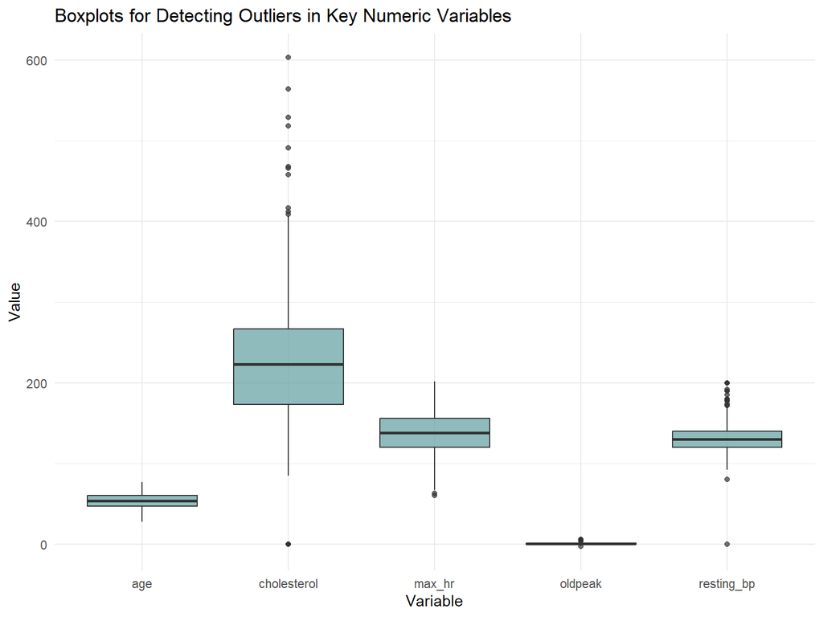

# Male and Female Distribution

- The bar chart shows the count of male vs female patients. This dataset contains shows significantly more males than females patients. This imbalance is important showing that raw counts alone can be misleading, hinting at sample bias and oversampling.

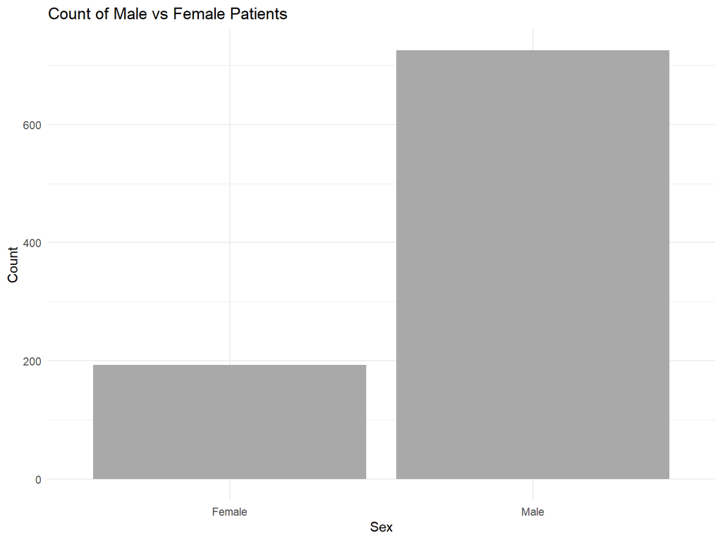

# Heart Disease Proportion by Sex

This proportion bar chart shows the prevalence of heart disease in males vs females. We used a proportion chart due to the raw count imbalance. A proportion bar chart is best to showcase a direct comparison, normalizing each group to a 100%, regardless of actual count.

- The proportion chart shows that about 63% of males have heart disease in comparison to only 26% of females that do. This correlates with real world known heart disease patterns.

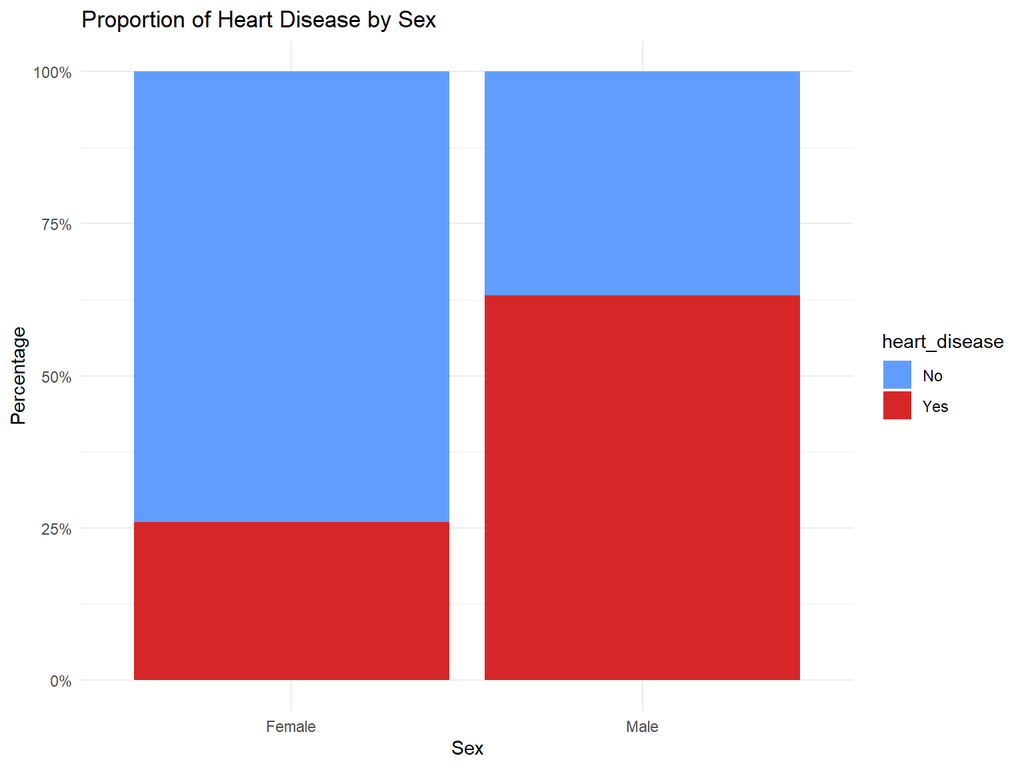

# Disease vs. No Disease

- What symptoms are typically associated with heart disease?
- What symptoms distinguish heart disease from no heart disease?

# Disease vs. No Disease

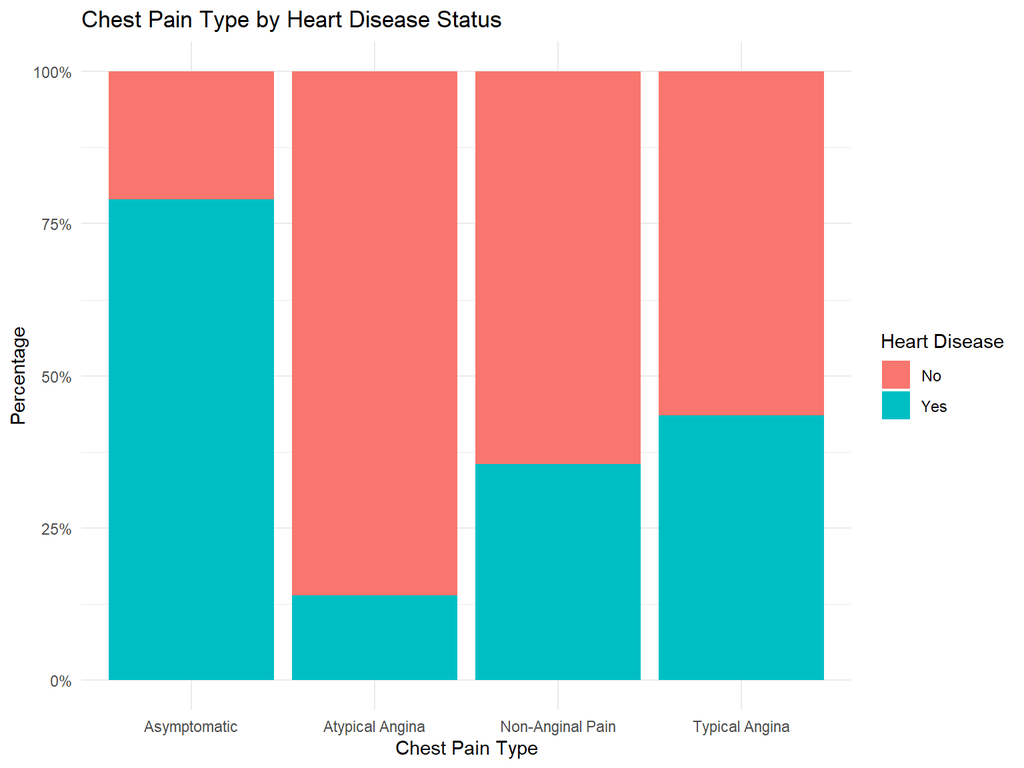

We can conclude from this chart that asymptomatic chest pain type is most prevalent among individuals with heart disease, followed by typical angina, non-anginal pain, and atypical angina. this establishes chest pain type as a meaningful symptom to explore by gender.

# Disease vs. No Disease

Oldpeak measures how much the ST segment drops during the exercise compared to rest. Higher values often indicate that the heart is not receiving enough oxygen.

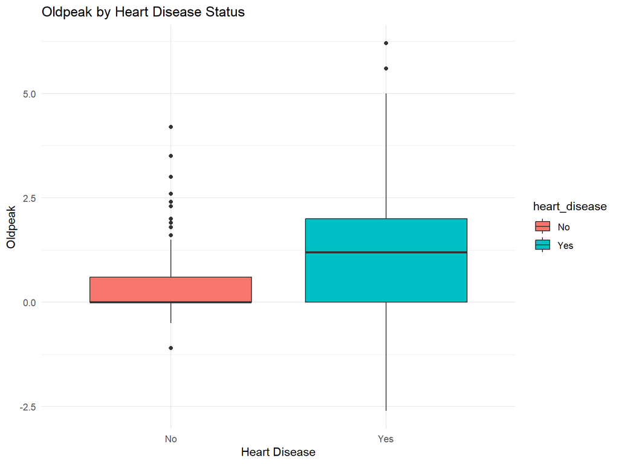

# Disease vs. No Disease

Individuals with heart disease tend to have lower maximum heart rates than those without the condition, shown by the distribution of the raincloud plot below. We can conclude that lower heart rates is a significant indicator of heart disease through the distance of the median points (red dots), but not the only indicator, as the graphs show an overlap.

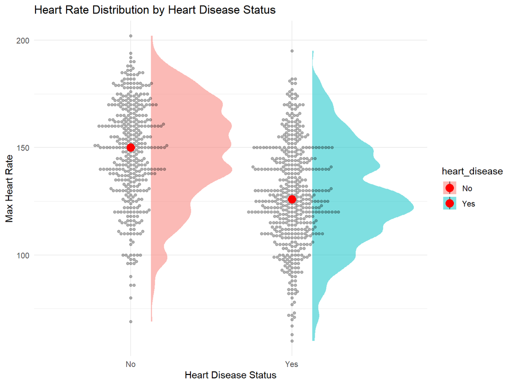

# Disease vs. No Disease

A down and flat ST slope is associated with patients with heart disease, this chart showcases patients with heart disease are similarly prone to a down or flat ST slope with minimal variance, reinforcing its diagnostic relevance.

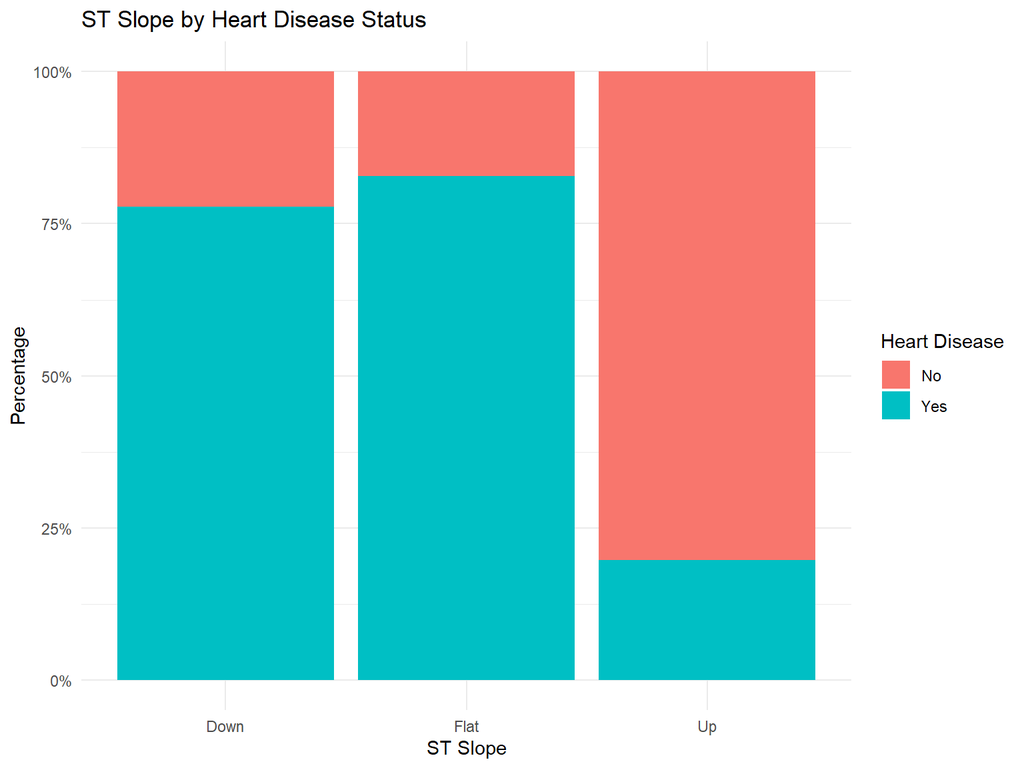

# Do these symptoms differ between men and women?

- We created a subset of the full heart dataset filtered to only keep individuals with heart disease.

```
##     age    sex  chest_pain_type resting_bp cholesterol fasting_bs
## 1    49 Female Non-Anginal Pain        160         180         No
## 2    48 Female     Asymptomatic        138         214         No
## 3    37   Male     Asymptomatic        140         207         No
## 4    58   Male  Atypical Angina        136         164         No
## 5    49   Male     Asymptomatic        140         234         No
## 6    38   Male     Asymptomatic        110         196         No
## 7    60   Male     Asymptomatic        100         248         No
## 8    36   Male  Atypical Angina        120         267         No
## 9    44   Male  Atypical Angina        150         288         No
## 10   53   Male Non-Anginal Pain        145         518         No
## 11   54   Male     Asymptomatic        125         224         No
## 12   41   Male     Asymptomatic        130         172         No
## 13   65   Male     Asymptomatic        140         306        Yes
## 14   54 Female Non-Anginal Pain        130         294         No
```

[output cut: 1003 more lines]

# Chest Pain Distribution by Sex

- This chart shows whether women with heart disease present more with atypical angina or asymptomatic chest pains, both of which are associated with heart disease. This graph shows that women and men with heart disease experience asymptomatic heart pain almost equally, however women experience atypical angina significantly more than men. Non-anginal pain and typical angina is seen more often in males than in females.

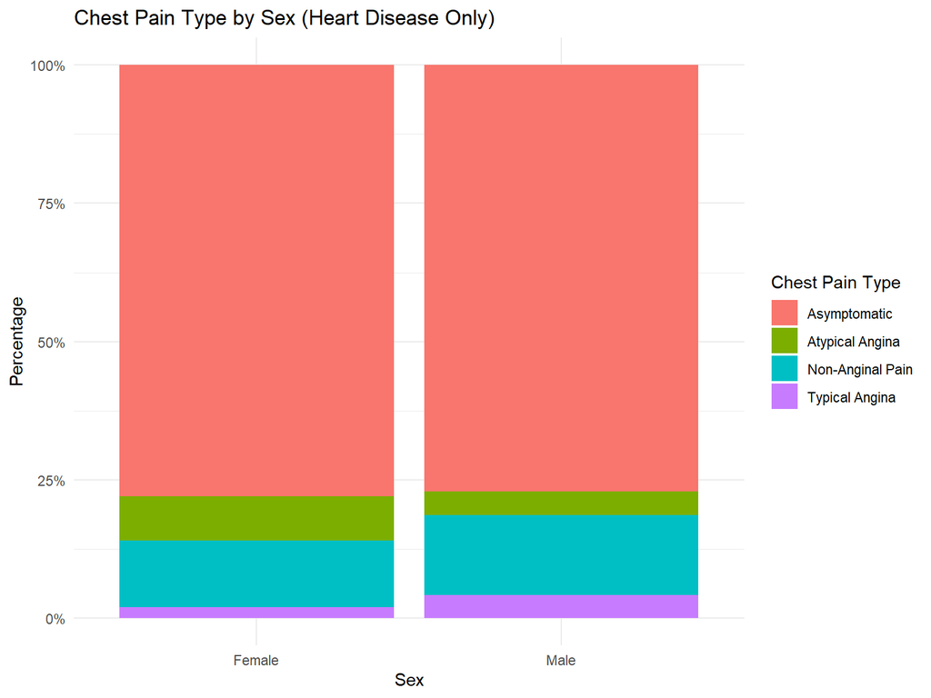

# Oldpeak Distribution by Sex

- The boxplot shows similar oldpeak symtoms between both sex.

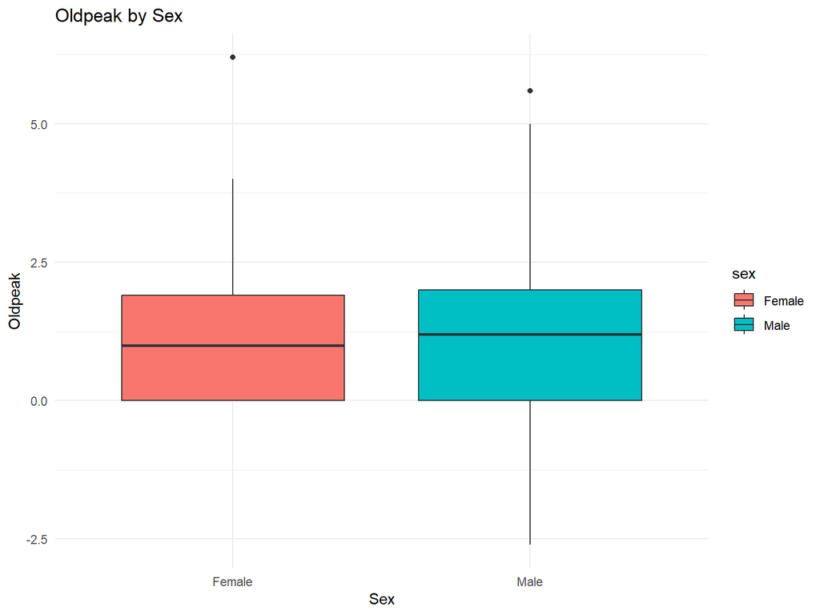

# Heart Rate Distribution by Sex

- The plot shows men and women differ in exercise response when disease is present in women than in men.

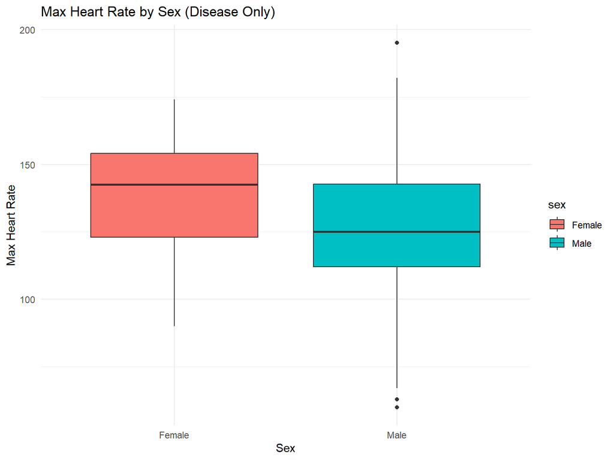

# ST Slope Distribution by Sex

- Both genders are fairly similar in ST slope distribution.

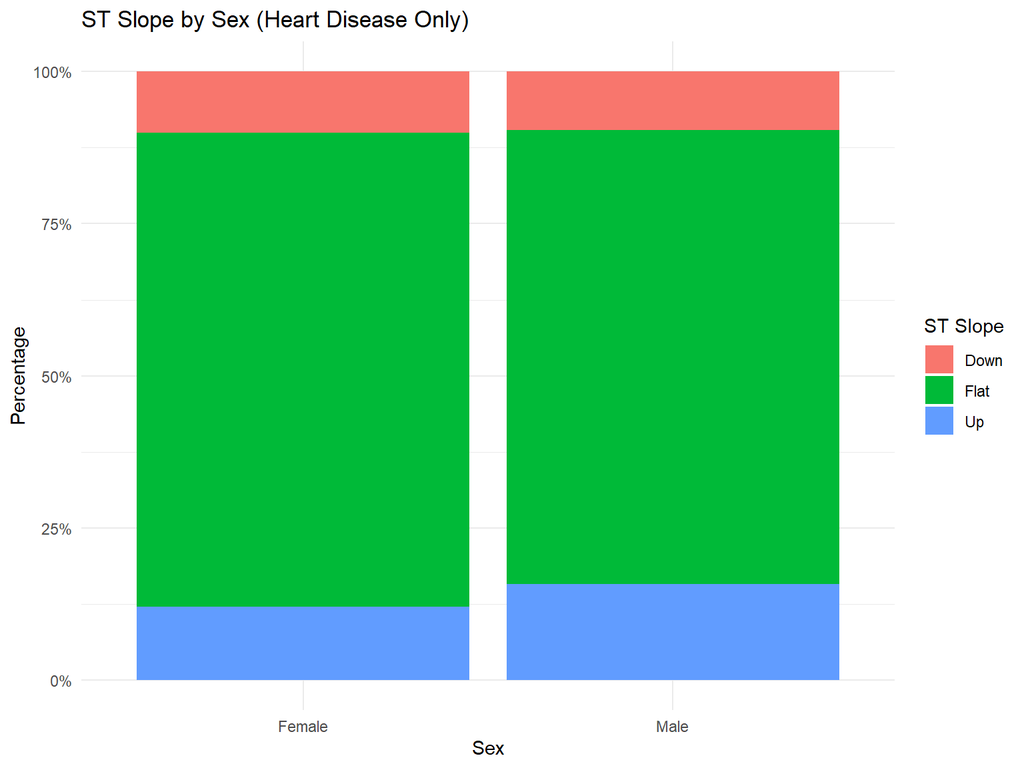

# Final Correlations and Purpose

- These findings suggest that gender may act as an interacting factor rather than a primary predictor. Analyzing heart disease data through gender is important because biological and physiological differences between male and female patients can influence how cardiovascular conditions present and progress. By separating the data by gender, this study allows for a more detailed understanding of whether heart disease patterns are consistent across groups or if meaningful differences exist. A gender-based analysis accounts for variation that may overly distort the relationship between heart failure and physiological measurements.